# Distributions and Simulation

- 🔗 Link to **all** Slides from Videos: [here](https://app.box.com/s/ae5f0yollihcggzr6bghkwabkdz2y7g9)

💻 Activities: 45 minutes

✅ Check-ins: 1

## Review: Statistical Distributions

▶️ [Required Video – Review of Statistical Distributions](https://www.youtube.com/embed/KddbZr-ssZc)

## Simulating in R

⏯ [Required Video – Simulating Data in R](https://www.youtube.com/embed/LNg7kQbXvU0)

📖 [Required Reading – *R Programming for Data Science* : Simulation](https://bookdown.org/rdpeng/rprogdatascience/simulation.html)

✅ **Check-in: The `r`, `p`, `q`, and `d` functions**

Try to predict what the following outputs will be **WITHOUT** running the code in R. Drawing pictures of the relevant distributions may help.

(Yes, it is very easy to “cheat” on this question. But this is for your practice, and I recommend you give it some thought.)

```r
## a
pnorm(-4, mean = 2, sd = 4)

## b
qnorm(.975, mean = 2, sd = 4)

## c
dnorm(1.5, mean = 2, sd = 4)

## d
rnorm(100, mean = 2, sd = 4)
```

## Setting a Random Number Seed

Functions like `rnorm()` rely on something called **pseudorandomness**. Because computers can never be *truly* random, complicated processes are implemented to make “random” number generation be so unpredictable as to behave like true randomness.

This means that projects involving simulation are harder to make **reproducible**. For example, here are two identical lines of code that give different results!

```r
rnorm(1, mean = 0, sd = 1)
```

```
## [1] 0.5679161
```

```r
rnorm(1, mean = 0, sd = 1)
```

```
## [1] -0.129151
```

Fortunately, pseudorandomness depends on a **seed**, which is an arbitrary number where the randomizing process starts. Normally, R will choose the seed for you, from a pre-generated vector:

```r
head(.Random.seed)
```

```
## [1]       10403           9  1390682053  -748960900 -1387643950   -32375987
```

However, you can also choose your own seed using the `set.seed()` function. This guarantees your results will be consistent:

```r
set.seed(1234)
rnorm(1, mean = 0, sd = 1)
```

```
## [1] -1.207066
```

```r
set.seed(1234)
rnorm(1, mean = 0, sd = 1)
```

```
## [1] -1.207066
```

(Of course, it doesn’t mean the results will be the same in every subsequent run, unless you reset the seed in between each line of code!)

```r
set.seed(1234)
rnorm(1, mean = 0, sd = 1)
```

```
## [1] -1.207066
```

```r
## Calling rnorm() again without a seed "resets" the seed!
rnorm(1, mean = 0, sd = 1)
```

```
## [1] 0.2774292
```

It is very important to always set a seed at the **beginning** of an R Markdown document that contains any random steps, so that your knitted results are consistent.

Note, though, that this only guarantees your knitted results will be the same *if the code has not changed*.

Changing up any part of the code will re-randomize everything that comes after it:

```r
set.seed(1234)
runif(1)
```

```
## [1] 0.1137034
```

```r
runif(1)
```

```
## [1] 0.6222994
```

```r
set.seed(1234)
rnorm(1)
```

```
## [1] -1.207066
```

```r
runif(1)
```

```
## [1] 0.6092747
```

### Plotting distributions

Here is the code that made one of the plots from the lecture video:

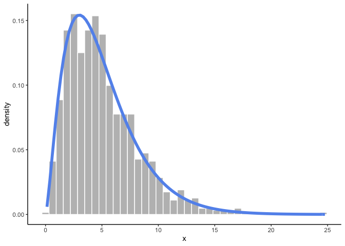

```r
my_samples <- data.frame(x = rchisq(1000, df = 5))

ggplot(my_samples, aes(x)) +
  geom_histogram(bins = 40, aes(y = ..density..), fill = "grey", col = "white") +
  stat_function(fun = ~dchisq(.x, df = 5), col = "cornflowerblue", lwd = 2) +
  theme_classic()
```

✅ **Check-in: Plotting Simulations**

Re-create this plot from the lecture slides: (The two colors are “cornflowerblue” and “deeppink”)

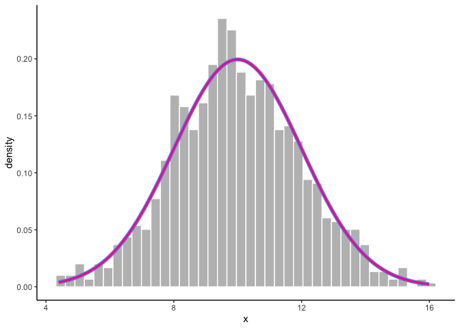